# Conferência do orçamento de juventude

Vitrine com dados sintéticos: nenhum número é do orçamento real

**Neste relatório (sumário)**

1. Veredito
2. O que precisa de atenção
3. Como ler as conferências
4. Todas as conferências
5. A série ano a ano
6. Participação no gasto do Executivo
7. Duas safras da base e o teste do recorte
8. Como este relatório foi feito
9. Glossário

## Veredito

209 números comparados: 208 conferem, 1 tem diferença explicada e nenhum ficou sem explicação.

Conferem

208

dentro da tolerância

Explicadas

1

fora da tolerância, com causa conhecida

Pendentes

0

nenhum número ficou sem causa

No total

209

números comparados com o publicado

Valores em reais de dez/2025 (fictícia), corrigidos pelo IPCA. Tolerância combinada antes da conta: R$ 1,00 por valor em reais, 0,05 ponto percentual para percentuais e nenhuma para contagens. Relatório gerado em 29/10/2026 às 16:54.

**DicaNada pendente**

Todos os números conferem ou têm a diferença explicada.

Esta conferência refez em R, sem usar o cálculo do script que gera os dados sintéticos, as contas do orçamento de juventude publicadas nos gabaritos sintéticos, calculados pelo script que gera os dados. Cada número calculado aqui foi posto lado a lado com o valor já publicado, chamado neste relatório de **gabarito**. A tolerância de cada comparação foi fixada antes de rodar a conta, para que ninguém ajuste o critério depois de ver o resultado. Diferença fora da tolerância não é corrigida em silêncio: aparece abaixo, com a causa provável e o que fazer.

## O que precisa de atenção

Nenhum número ficou fora da tolerância sem explicação.

### Diferenças com causa conhecida

Este número ficou fora da tolerância por um motivo já conhecido e documentado. Causa marcada com “(inferido)” é hipótese, ainda não confirmada na fonte.

Recorte de juventude, safra antiga × safra nova, 2005 a 2024: maior diferença em reais (anos diferentes: 2008, 2009, 2010, 2011)

**Valor calculado em R**

R$ 7.057.582,00

**Gabarito (valor de referência)**

R$ 0,00

**Diferença**

R$ 7.057.582,00 (tolerância: até R$ 1,00)

**Fonte do gabarito**

Checagem interna: as duas safras do recorte de juventude, comparadas na seção Duas safras

**Causa provável**

Fenômeno criado pelo gerador (scripts/gerar_dados_sinteticos.R): de 2008 a 2011 a safra nova tem linhas a mais, da ação ZD01 (palavra-chave chave-delta, acrescentada depois) e da ZM02 (inclusão manual).

**O que fazer**

Nenhuma correção: o recorte usa a safra nova em todos os anos. Detalhe na seção Duas safras do relatório.

## Como ler as conferências

Cada linha da conferência compara **um número calculado em R** com **o mesmo número já publicado** (nas checagens internas, com o valor que a própria base exige). A comparação tem três resultados possíveis:

- **✓ Confere**: a diferença ficou dentro da tolerância.
- **ⓘ Explicada**: a diferença passou da tolerância, mas a causa é conhecida e está escrita na linha (por exemplo, o texto publicado usa uma versão mais antiga da base).
- **✗ Diverge**: a diferença passou da tolerância e ninguém sabe ainda por quê. Esse número não deve ir para nenhum texto antes de ser revisto.

As tolerâncias são as mesmas para todo o relatório, decididas antes da conta: **R$ 1,00** para valores em reais, **0,05 ponto percentual** para percentuais (cobre arredondamentos da série publicada) e **nenhuma** para contagens, como número de programas e de ações, e para listas, como a ordem dos anos de maior valor.

As conferências se agrupam pela fonte do gabarito, na ordem de autoridade das fontes combinada antes da conta (definida em `config/config.yml`). A última família reúne as checagens que não dependem de número publicado.

### Gabaritos sintéticos

- **O que foi comparado:** os totais por ano e por fase, o total e a média do período, a divisão por grupo de despesa, o valor de algumas ações, a taxa de execução, a participação no gasto do Executivo e o ano de maior participação, o gasto do Executivo usado como denominador, as contagens, a concentração e os quatro anos de maior dotação.
- **Com o quê:** os valores que `scripts/gerar_dados_sinteticos.R` calcula a partir da verdade inventada, só com o R básico, por um caminho independente do pipeline.
- **Tolerância:** R$ 1,00 por valor em reais, 0,05 ponto percentual para percentuais, nenhuma para contagens e nenhuma para listas (mesmos itens, na mesma ordem).
- **Se divergir:** nos dados sintéticos, uma divergência indica erro no pipeline ou no gerador: comparar as duas contas para o mesmo número.

**Resultado nesta rodada:** 203 números; 203 conferem.

### Checagens internas

- **O que foi comparado:** propriedades que não dependem de um número publicado. A base da União é idêntica nas duas safras de 2005 a 2024; as duas safras do recorte de juventude só diferem nos anos já medidos e explicados; o recorte cobre todas as linhas; as ações obrigatórias da configuração (`ZM01`) estão presentes; o total de cada fase é o mesmo somado por quatro caminhos (linhas, anos, grupos de despesa e ações); o fator do IPCA de 2019 é o esperado na configuração (esta linha é um registro: com outro fator, a conferência para com erro antes de chegar aqui).
- **Com o quê:** com a própria base, recalculada por outro caminho, e com a configuração.
- **Tolerância:** R$ 1,00 por valor em reais, nenhuma para contagens e 0,0000001 para fatores de correção.
- **Se divergir:** uma checagem interna que falha indica erro de leitura ou de filtro nesta conferência, não no texto publicado. Ela deve ser resolvida antes de olhar as outras famílias.

**Resultado nesta rodada:** 6 números; 5 conferem; 1 com divergência explicada.

## Todas as conferências

A lista completa tem 209 linhas, com as que pedem atenção primeiro. Use a caixa de busca para achar um ano, uma fase ou uma fonte. O mesmo conteúdo está em `saidas/divergencias.csv`.

| Situação | O que foi conferido (fonte do gabarito) | Calculado em R | Gabarito | Diferença (tolerância) |
| --- | --- | --- | --- | --- |
| ⓘ Explicada | Recorte de juventude, safra antiga × safra nova, 2005 a 2024: maior diferença em reais (anos diferentes: 2008, 2009, 2010, 2011) (fonte: Checagem interna: as duas safras do recorte de juventude, compa… | R$ 7.057.582,00 | R$ 0,00 | R$ 7.057.582,00 (até R$ 1,00) |
| ✓ Confere | Ano de maior participação do recorte no empenhado do Executivo (fonte: scripts/gerar_dados_sinteticos.R (verdade sintética)) | 2009 | 2009 | nenhuma (exata, na mesma ordem) |
| ✓ Confere | Empenhado do Executivo em 2005 (nominal) (fonte: scripts/gerar_dados_sinteticos.R (verdade sintética)) | R$ 406.668.448,00 | R$ 406.668.448,00 | R$ 0,00 (até R$ 1,00) |
| ✓ Confere | Empenhado do Executivo em 2006 (nominal) (fonte: scripts/gerar_dados_sinteticos.R (verdade sintética)) | R$ 457.164.769,00 | R$ 457.164.769,00 | R$ 0,00 (até R$ 1,00) |
| ✓ Confere | Empenhado do Executivo em 2007 (nominal) (fonte: scripts/gerar_dados_sinteticos.R (verdade sintética)) | R$ 480.944.371,00 | R$ 480.944.371,00 | R$ 0,00 (até R$ 1,00) |
| ✓ Confere | Empenhado do Executivo em 2008 (nominal) (fonte: scripts/gerar_dados_sinteticos.R (verdade sintética)) | R$ 536.903.008,00 | R$ 536.903.008,00 | R$ 0,00 (até R$ 1,00) |
| ✓ Confere | Empenhado do Executivo em 2009 (nominal) (fonte: scripts/gerar_dados_sinteticos.R (verdade sintética)) | R$ 558.653.360,00 | R$ 558.653.360,00 | R$ 0,00 (até R$ 1,00) |
| ✓ Confere | Empenhado do Executivo em 2010 (nominal) (fonte: scripts/gerar_dados_sinteticos.R (verdade sintética)) | R$ 576.934.227,00 | R$ 576.934.227,00 | R$ 0,00 (até R$ 1,00) |
| ✓ Confere | Empenhado do Executivo em 2011 (nominal) (fonte: scripts/gerar_dados_sinteticos.R (verdade sintética)) | R$ 624.170.575,00 | R$ 624.170.575,00 | R$ 0,00 (até R$ 1,00) |
| ✓ Confere | Empenhado do Executivo em 2012 (nominal) (fonte: scripts/gerar_dados_sinteticos.R (verdade sintética)) | R$ 604.061.617,00 | R$ 604.061.617,00 | R$ 0,00 (até R$ 1,00) |

[output cut: 199 more lines]

| O que foi conferido (fonte do gabarito) | Situação e valores |
| --- | --- |
| Recorte de juventude, safra antiga × safra nova, 2005 a 2024: maior diferença em reais (anos diferentes: 2008, 2009, 2010, 2011) (fonte: Checagem interna: as duas safras do recorte de juventude, compa… | ⓘ Explicada |
| Ano de maior participação do recorte no empenhado do Executivo (fonte: scripts/gerar_dados_sinteticos.R (verdade sintética)) | ✓ Confere |
| Empenhado do Executivo em 2005 (nominal) (fonte: scripts/gerar_dados_sinteticos.R (verdade sintética)) | ✓ Confere |
| Empenhado do Executivo em 2006 (nominal) (fonte: scripts/gerar_dados_sinteticos.R (verdade sintética)) | ✓ Confere |
| Empenhado do Executivo em 2007 (nominal) (fonte: scripts/gerar_dados_sinteticos.R (verdade sintética)) | ✓ Confere |
| Empenhado do Executivo em 2008 (nominal) (fonte: scripts/gerar_dados_sinteticos.R (verdade sintética)) | ✓ Confere |
| Empenhado do Executivo em 2009 (nominal) (fonte: scripts/gerar_dados_sinteticos.R (verdade sintética)) | ✓ Confere |
| Empenhado do Executivo em 2010 (nominal) (fonte: scripts/gerar_dados_sinteticos.R (verdade sintética)) | ✓ Confere |
| Empenhado do Executivo em 2011 (nominal) (fonte: scripts/gerar_dados_sinteticos.R (verdade sintética)) | ✓ Confere |
| Empenhado do Executivo em 2012 (nominal) (fonte: scripts/gerar_dados_sinteticos.R (verdade sintética)) | ✓ Confere |

[output cut: 199 more lines]

| O que foi conferido (fonte do gabarito) | Situação e valores |
| --- | --- |
| Recorte de juventude, safra antiga × safra nova, 2005 a 2024: maior diferença em reais (anos diferentes: 2008, 2009, 2010, 2011) (fonte: Checagem interna: as duas safras do recorte de juventude, compa… | **ⓘ Explicada** Calculado em R: R$ 7.057.582,00 Gabarito: R$ 0,00 Diferença: R$ 7.057.582,00 (até R$ 1,00) |
| Ano de maior participação do recorte no empenhado do Executivo (fonte: scripts/gerar_dados_sinteticos.R (verdade sintética)) | **✓ Confere** Calculado em R: 2009 Gabarito: 2009 Diferença: nenhuma (exata, na mesma ordem) |
| Empenhado do Executivo em 2005 (nominal) (fonte: scripts/gerar_dados_sinteticos.R (verdade sintética)) | **✓ Confere** Calculado em R: R$ 406.668.448,00 Gabarito: R$ 406.668.448,00 Diferença: R$ 0,00 (até R$ 1,00) |
| Empenhado do Executivo em 2006 (nominal) (fonte: scripts/gerar_dados_sinteticos.R (verdade sintética)) | **✓ Confere** Calculado em R: R$ 457.164.769,00 Gabarito: R$ 457.164.769,00 Diferença: R$ 0,00 (até R$ 1,00) |
| Empenhado do Executivo em 2007 (nominal) (fonte: scripts/gerar_dados_sinteticos.R (verdade sintética)) | **✓ Confere** Calculado em R: R$ 480.944.371,00 Gabarito: R$ 480.944.371,00 Diferença: R$ 0,00 (até R$ 1,00) |
| Empenhado do Executivo em 2008 (nominal) (fonte: scripts/gerar_dados_sinteticos.R (verdade sintética)) | **✓ Confere** Calculado em R: R$ 536.903.008,00 Gabarito: R$ 536.903.008,00 Diferença: R$ 0,00 (até R$ 1,00) |
| Empenhado do Executivo em 2009 (nominal) (fonte: scripts/gerar_dados_sinteticos.R (verdade sintética)) | **✓ Confere** Calculado em R: R$ 558.653.360,00 Gabarito: R$ 558.653.360,00 Diferença: R$ 0,00 (até R$ 1,00) |
| Empenhado do Executivo em 2010 (nominal) (fonte: scripts/gerar_dados_sinteticos.R (verdade sintética)) | **✓ Confere** Calculado em R: R$ 576.934.227,00 Gabarito: R$ 576.934.227,00 Diferença: R$ 0,00 (até R$ 1,00) |
| Empenhado do Executivo em 2011 (nominal) (fonte: scripts/gerar_dados_sinteticos.R (verdade sintética)) | **✓ Confere** Calculado em R: R$ 624.170.575,00 Gabarito: R$ 624.170.575,00 Diferença: R$ 0,00 (até R$ 1,00) |
| Empenhado do Executivo em 2012 (nominal) (fonte: scripts/gerar_dados_sinteticos.R (verdade sintética)) | **✓ Confere** Calculado em R: R$ 604.061.617,00 Gabarito: R$ 604.061.617,00 Diferença: R$ 0,00 (até R$ 1,00) |
| Empenhado do Executivo em 2013 (nominal) (fonte: scripts/gerar_dados_sinteticos.R (verdade sintética)) | **✓ Confere** Calculado em R: R$ 702.660.437,00 Gabarito: R$ 702.660.437,00 Diferença: R$ 0,00 (até R$ 1,00) |
| Empenhado do Executivo em 2014 (nominal) (fonte: scripts/gerar_dados_sinteticos.R (verdade sintética)) | **✓ Confere** Calculado em R: R$ 703.735.844,00 Gabarito: R$ 703.735.844,00 Diferença: R$ 0,00 (até R$ 1,00) |
| Empenhado do Executivo em 2015 (nominal) (fonte: scripts/gerar_dados_sinteticos.R (verdade sintética)) | **✓ Confere** Calculado em R: R$ 718.245.101,00 Gabarito: R$ 718.245.101,00 Diferença: R$ 0,00 (até R$ 1,00) |
| Empenhado do Executivo em 2016 (nominal) (fonte: scripts/gerar_dados_sinteticos.R (verdade sintética)) | **✓ Confere** Calculado em R: R$ 827.105.135,00 Gabarito: R$ 827.105.135,00 Diferença: R$ 0,00 (até R$ 1,00) |
| Empenhado do Executivo em 2017 (nominal) (fonte: scripts/gerar_dados_sinteticos.R (verdade sintética)) | **✓ Confere** Calculado em R: R$ 744.676.857,00 Gabarito: R$ 744.676.857,00 Diferença: R$ 0,00 (até R$ 1,00) |
| Empenhado do Executivo em 2018 (nominal) (fonte: scripts/gerar_dados_sinteticos.R (verdade sintética)) | **✓ Confere** Calculado em R: R$ 917.284.551,00 Gabarito: R$ 917.284.551,00 Diferença: R$ 0,00 (até R$ 1,00) |
| Empenhado do Executivo em 2019 (nominal) (fonte: scripts/gerar_dados_sinteticos.R (verdade sintética)) | **✓ Confere** Calculado em R: R$ 896.987.728,00 Gabarito: R$ 896.987.728,00 Diferença: R$ 0,00 (até R$ 1,00) |
| Empenhado do Executivo em 2020 (nominal) (fonte: scripts/gerar_dados_sinteticos.R (verdade sintética)) | **✓ Confere** Calculado em R: R$ 980.339.171,00 Gabarito: R$ 980.339.171,00 Diferença: R$ 0,00 (até R$ 1,00) |
| Empenhado do Executivo em 2021 (nominal) (fonte: scripts/gerar_dados_sinteticos.R (verdade sintética)) | **✓ Confere** Calculado em R: R$ 1.075.178.177,00 Gabarito: R$ 1.075.178.177,00 Diferença: R$ 0,00 (até R$ 1,00) |
| Empenhado do Executivo em 2022 (nominal) (fonte: scripts/gerar_dados_sinteticos.R (verdade sintética)) | **✓ Confere** Calculado em R: R$ 1.086.477.536,00 Gabarito: R$ 1.086.477.536,00 Diferença: R$ 0,00 (até R$ 1,00) |
| Empenhado do Executivo em 2023 (nominal) (fonte: scripts/gerar_dados_sinteticos.R (verdade sintética)) | **✓ Confere** Calculado em R: R$ 1.126.498.642,00 Gabarito: R$ 1.126.498.642,00 Diferença: R$ 0,00 (até R$ 1,00) |
| Empenhado do Executivo em 2024 (nominal) (fonte: scripts/gerar_dados_sinteticos.R (verdade sintética)) | **✓ Confere** Calculado em R: R$ 1.205.777.807,00 Gabarito: R$ 1.205.777.807,00 Diferença: R$ 0,00 (até R$ 1,00) |
| Média anual do recorte de 2005 a 2025, dotacao_atual (fonte: scripts/gerar_dados_sinteticos.R (verdade sintética)) | **✓ Confere** Calculado em R: R$ 97.117.974,46 Gabarito: R$ 97.117.974,46 Diferença: -R$ 0,00 (até R$ 1,00) |
| Média anual do recorte de 2005 a 2025, dotacao_inicial (fonte: scripts/gerar_dados_sinteticos.R (verdade sintética)) | **✓ Confere** Calculado em R: R$ 91.944.142,64 Gabarito: R$ 91.944.142,64 Diferença: R$ 0,00 (até R$ 1,00) |
| Média anual do recorte de 2005 a 2025, empenhado (fonte: scripts/gerar_dados_sinteticos.R (verdade sintética)) | **✓ Confere** Calculado em R: R$ 82.012.549,90 Gabarito: R$ 82.012.549,90 Diferença: R$ 0,00 (até R$ 1,00) |
| Média anual do recorte de 2005 a 2025, liquidado (fonte: scripts/gerar_dados_sinteticos.R (verdade sintética)) | **✓ Confere** Calculado em R: R$ 76.091.369,71 Gabarito: R$ 76.091.369,71 Diferença: -R$ 0,00 (até R$ 1,00) |
| Média anual do recorte de 2005 a 2025, pago (fonte: scripts/gerar_dados_sinteticos.R (verdade sintética)) | **✓ Confere** Calculado em R: R$ 72.155.946,62 Gabarito: R$ 72.155.946,62 Diferença: R$ 0,00 (até R$ 1,00) |
| Média anual do recorte de 2005 a 2025, projeto_lei (fonte: scripts/gerar_dados_sinteticos.R (verdade sintética)) | **✓ Confere** Calculado em R: R$ 92.031.309,63 Gabarito: R$ 92.031.309,63 Diferença: R$ 0,00 (até R$ 1,00) |
| Ações distintas no recorte (fonte: scripts/gerar_dados_sinteticos.R (verdade sintética)) | **✓ Confere** Calculado em R: 9 Gabarito: 9 Diferença: 0 (exata) |
| Programas distintos no recorte (fonte: scripts/gerar_dados_sinteticos.R (verdade sintética)) | **✓ Confere** Calculado em R: 5 Gabarito: 5 Diferença: 0 (exata) |

[output cut: 179 more lines]

## A série de 2005 a 2025

Os valores abaixo são a soma das linhas do recorte de juventude em cada ano, corrigidos pela inflação até dez/2025 (fictícia). A correção usa o IPCA acumulado de cada ano até a data de referência, para que um real de 2005 e um real de 2025 possam ser comparados.

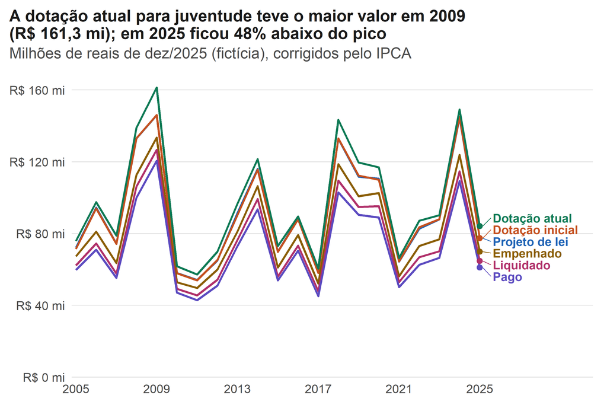

Fonte: arquivos sintéticos no formato do SIOP, gerados por scripts/gerar_dados_sinteticos.R, recorte de juventude do arquivo juventude_safra_nova.csv (safra nova); correção pelo IPCA com os fatores de ipca_fatores.csv. Cálculo desta conferência em R.

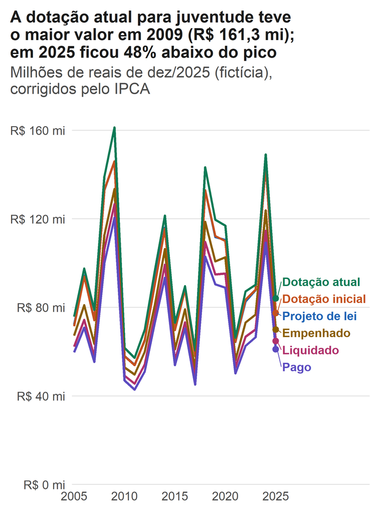

Fonte: arquivos sintéticos no formato do SIOP, gerados por scripts/gerar_dados_sinteticos.R, recorte de juventude do arquivo juventude_safra_nova.csv (safra nova); correção pelo IPCA com os fatores de ipca_fatores.csv. Cálculo desta conferência em R.

No período inteiro, a dotação atual somou **R$ 2.039,48 mi** (média de R$ 97,12 mi por ano). Do que foi autorizado, 84,4% foi empenhado (taxa de execução do período). Os quatro anos de maior dotação atual foram 2009, 2024, 2018, 2008.

**Ver os números do gráfico (tabela)**

Arraste a tabela para o lado para ver todas as colunas.

| ano | Projeto de lei | Dotação inicial | Dotação atual | Empenhado | Liquidado | Pago |
| --- | --- | --- | --- | --- | --- | --- |
| 2005 | R$ 72,27 mi | R$ 71,46 mi | R$ 75,87 mi | R$ 67,31 mi | R$ 62,27 mi | R$ 59,76 mi |
| 2006 | R$ 94,46 mi | R$ 93,92 mi | R$ 97,56 mi | R$ 81,02 mi | R$ 74,45 mi | R$ 70,91 mi |
| 2007 | R$ 74,31 mi | R$ 74,23 mi | R$ 78,81 mi | R$ 63,55 mi | R$ 57,70 mi | R$ 55,35 mi |
| 2008 | R$ 132,93 mi | R$ 133,14 mi | R$ 139,03 mi | R$ 112,67 mi | R$ 106,15 mi | R$ 99,98 mi |
| 2009 | R$ 145,88 mi | R$ 145,99 mi | R$ 161,30 mi | R$ 133,49 mi | R$ 126,67 mi | R$ 120,49 mi |
| 2010 | R$ 58,05 mi | R$ 57,96 mi | R$ 61,75 mi | R$ 52,87 mi | R$ 49,19 mi | R$ 47,04 mi |
| 2011 | R$ 54,15 mi | R$ 53,91 mi | R$ 57,19 mi | R$ 49,69 mi | R$ 45,57 mi | R$ 42,89 mi |
| 2012 | R$ 64,93 mi | R$ 65,20 mi | R$ 69,90 mi | R$ 59,96 mi | R$ 54,21 mi | R$ 51,02 mi |
| 2013 | R$ 91,34 mi | R$ 90,26 mi | R$ 96,56 mi | R$ 81,04 mi | R$ 76,39 mi | R$ 72,94 mi |
| 2014 | R$ 116,08 mi | R$ 115,62 mi | R$ 121,50 mi | R$ 106,41 mi | R$ 99,29 mi | R$ 93,47 mi |
| 2015 | R$ 69,94 mi | R$ 69,72 mi | R$ 73,11 mi | R$ 61,03 mi | R$ 56,03 mi | R$ 53,91 mi |
| 2016 | R$ 88,40 mi | R$ 88,00 mi | R$ 89,56 mi | R$ 79,13 mi | R$ 73,27 mi | R$ 70,48 mi |
| 2017 | R$ 58,04 mi | R$ 57,98 mi | R$ 60,53 mi | R$ 52,20 mi | R$ 47,76 mi | R$ 45,09 mi |
| 2018 | R$ 132,80 mi | R$ 132,96 mi | R$ 143,28 mi | R$ 118,65 mi | R$ 109,54 mi | R$ 102,95 mi |
| 2019 | R$ 111,74 mi | R$ 112,30 mi | R$ 119,57 mi | R$ 100,80 mi | R$ 94,85 mi | R$ 90,41 mi |
| 2020 | R$ 110,55 mi | R$ 109,94 mi | R$ 116,94 mi | R$ 102,59 mi | R$ 95,31 mi | R$ 88,94 mi |
| 2021 | R$ 64,33 mi | R$ 64,43 mi | R$ 66,36 mi | R$ 56,18 mi | R$ 52,98 mi | R$ 50,15 mi |
| 2022 | R$ 82,68 mi | R$ 83,47 mi | R$ 87,22 mi | R$ 73,12 mi | R$ 66,80 mi | R$ 62,66 mi |
| 2023 | R$ 87,90 mi | R$ 87,94 mi | R$ 90,27 mi | R$ 76,78 mi | R$ 70,08 mi | R$ 66,50 mi |
| 2024 | R$ 144,51 mi | R$ 144,99 mi | R$ 149,11 mi | R$ 123,86 mi | R$ 114,62 mi | R$ 109,28 mi |
| 2025 | R$ 77,38 mi | R$ 77,40 mi | R$ 84,06 mi | R$ 69,91 mi | R$ 64,78 mi | R$ 61,05 mi |

Milhões de reais de dez/2025 (fictícia), com duas casas decimais.

## Participação no gasto do Executivo

A participação compara o que foi **empenhado** para juventude com o que o Poder Executivo inteiro empenhou no mesmo ano, nos grupos de despesa 1, 3, 4 e 5 (ver GND no glossário). Ficam de fora a Câmara fictícia, os tribunais fictícios (órgãos que começam com 1), os encargos financeiros fictícios e as operações oficiais de crédito fictícias. A lista de órgãos excluídos está em `config/config.yml`. As duas partes da conta estão em valores do próprio ano, então a correção pela inflação não muda o resultado.

Em 2025 o gasto do Executivo é **estimado**: a base nova da União só traz o total por grupo de despesa, sem separar os órgãos, e a base antiga tem esse ano só em parte. A conferência calcula na base antiga a fração do Executivo no total da União naquele mesmo ano, fase a fase, e aplica essa fração ao total da base nova, o mesmo método usado pelo cálculo do script que gera os dados sintéticos.

Arraste a tabela para o lado para ver todas as colunas.

| Ano | Empenhado de juventude | Empenhado do Executivo | Participação | Executivo estimado? |
| --- | --- | --- | --- | --- |
| 2005 | R$ 0,023 bi | R$ 0,407 bi | 5,56% | Não |
| 2006 | R$ 0,029 bi | R$ 0,457 bi | 6,44% | Não |
| 2007 | R$ 0,024 bi | R$ 0,481 bi | 5,08% | Não |
| 2008 | R$ 0,047 bi | R$ 0,537 bi | 8,78% | Não |
| 2009 | R$ 0,060 bi | R$ 0,559 bi | 10,77% | Não |
| 2010 | R$ 0,025 bi | R$ 0,577 bi | 4,30% | Não |
| 2011 | R$ 0,024 bi | R$ 0,624 bi | 3,88% | Não |
| 2012 | R$ 0,030 bi | R$ 0,604 bi | 5,02% | Não |
| 2013 | R$ 0,042 bi | R$ 0,703 bi | 6,01% | Não |
| 2014 | R$ 0,060 bi | R$ 0,704 bi | 8,55% | Não |
| 2015 | R$ 0,036 bi | R$ 0,718 bi | 4,96% | Não |
| 2016 | R$ 0,048 bi | R$ 0,827 bi | 5,86% | Não |
| 2017 | R$ 0,034 bi | R$ 0,745 bi | 4,53% | Não |
| 2018 | R$ 0,082 bi | R$ 0,917 bi | 8,96% | Não |
| 2019 | R$ 0,073 bi | R$ 0,897 bi | 8,10% | Não |
| 2020 | R$ 0,079 bi | R$ 0,980 bi | 8,07% | Não |
| 2021 | R$ 0,045 bi | R$ 1,075 bi | 4,22% | Não |
| 2022 | R$ 0,062 bi | R$ 1,086 bi | 5,73% | Não |
| 2023 | R$ 0,069 bi | R$ 1,126 bi | 6,14% | Não |
| 2024 | R$ 0,117 bi | R$ 1,206 bi | 9,66% | Não |
| 2025 | R$ 0,070 bi | R$ 1,466 bi | 4,77% | Sim |

Valores nominais (do próprio ano), em bilhões de reais.

## Duas safras da base e o teste do recorte

A base de dados (fonte: arquivos sintéticos no formato do SIOP, gerados por scripts/gerar_dados_sinteticos.R) foi extraída em duas datas, e cada extração é chamada aqui de **safra**. A **safra antiga** foi extraída na data fictícia da primeira extração; a **safra nova**, na data fictícia da segunda extração. As duas deveriam trazer os mesmos valores para os anos já encerrados, mas não trazem em todos os casos. Esta seção mostra onde elas diferem e por que a conferência usa cada uma.

**Por que o recorte de juventude vem da safra nova.** De 2008 a 2011 a safra nova tem linhas que a antiga não tem: ações trazidas por palavras-chave acrescentadas depois e ações incluídas à mão no recorte (a tabela mais abaixo mostra cada uma). Os números publicados usam a safra nova; usar a antiga deixaria essas linhas de fora e nenhum deles seria reproduzido. A diferença entre as safras entra na conferência como divergência explicada, e não como correção.

**Por que o gasto do Executivo vem da safra antiga.** A base nova da União só traz totais por grupo de despesa, sem o órgão. Sem o órgão não dá para separar o Executivo do Legislativo e do Judiciário. A base antiga tem o órgão, e nos anos de 2005 a 2024 as duas são iguais ao centavo (tabela abaixo). Para 2025, que a base antiga não traz completo, o valor é estimado.

### Recorte de juventude: safra antiga e safra nova

De 2005 a 2024, em **16 de 20 anos** as duas safras têm o mesmo número de linhas e os mesmos valores, ao centavo, nas seis fases. Os anos com diferença são 2008, 2009, 2010, 2011. A tabela mostra a dotação atual.

Arraste a tabela para o lado para ver todas as colunas.

| Ano | Safra nova | Safra antiga | Diferença | Linhas (nova) | Linhas (antiga) | Situação |
| --- | --- | --- | --- | --- | --- | --- |
| 2005 | R$ 25,48 mi | R$ 25,48 mi | R$ 0,00 mi | 13 | 13 | ✓ Iguais |
| 2006 | R$ 35,47 mi | R$ 35,47 mi | R$ 0,00 mi | 13 | 13 | ✓ Iguais |
| 2007 | R$ 30,31 mi | R$ 30,31 mi | R$ 0,00 mi | 13 | 13 | ✓ Iguais |
| 2008 | R$ 58,14 mi | R$ 52,54 mi | R$ 5,59 mi | 17 | 13 | ≠ Diferentes |
| 2009 | R$ 72,68 mi | R$ 65,62 mi | R$ 7,06 mi | 17 | 13 | ≠ Diferentes |
| 2010 | R$ 28,98 mi | R$ 26,65 mi | R$ 2,33 mi | 17 | 13 | ≠ Diferentes |
| 2011 | R$ 27,90 mi | R$ 25,20 mi | R$ 2,70 mi | 17 | 13 | ≠ Diferentes |
| 2012 | R$ 35,33 mi | R$ 35,33 mi | R$ 0,00 mi | 13 | 13 | ✓ Iguais |
| 2013 | R$ 50,35 mi | R$ 50,35 mi | R$ 0,00 mi | 13 | 13 | ✓ Iguais |
| 2014 | R$ 68,73 mi | R$ 68,73 mi | R$ 0,00 mi | 13 | 13 | ✓ Iguais |
| 2015 | R$ 42,70 mi | R$ 42,70 mi | R$ 0,00 mi | 13 | 13 | ✓ Iguais |
| 2016 | R$ 54,83 mi | R$ 54,83 mi | R$ 0,00 mi | 13 | 13 | ✓ Iguais |
| 2017 | R$ 39,09 mi | R$ 39,09 mi | R$ 0,00 mi | 15 | 15 | ✓ Iguais |
| 2018 | R$ 99,27 mi | R$ 99,27 mi | R$ 0,00 mi | 15 | 15 | ✓ Iguais |
| 2019 | R$ 86,14 mi | R$ 86,14 mi | R$ 0,00 mi | 15 | 15 | ✓ Iguais |
| 2020 | R$ 90,13 mi | R$ 90,13 mi | R$ 0,00 mi | 15 | 15 | ✓ Iguais |
| 2021 | R$ 53,64 mi | R$ 53,64 mi | R$ 0,00 mi | 15 | 15 | ✓ Iguais |
| 2022 | R$ 74,31 mi | R$ 74,31 mi | R$ 0,00 mi | 15 | 15 | ✓ Iguais |
| 2023 | R$ 81,31 mi | R$ 81,31 mi | R$ 0,00 mi | 13 | 13 | ✓ Iguais |
| 2024 | R$ 140,28 mi | R$ 140,28 mi | R$ 0,00 mi | 13 | 13 | ✓ Iguais |

Dotação atual em valores nominais, em milhões de reais. A situação considera o valor e o número de linhas; a diferença ao centavo, por ação, está na tabela seguinte.

As diferenças vêm de 2 ações. A tabela mostra, por ano e ação, quantas linhas cada safra tem e a palavra-chave que trouxe a ação para o recorte (vazio quando a ação foi incluída à mão).

Arraste a tabela para o lado para ver todas as colunas.

| Ano | Programa | Ação | Linhas (nova) | Linhas (antiga) | Dotação atual (nova) | Dotação atual (antiga) | Diferença | Palavra-chave |
| --- | --- | --- | --- | --- | --- | --- | --- | --- |
| 2008 | Z103 | ZD01 | 2 | 0 | R$ 4.235.224,00 | R$ 0,00 | R$ 4.235.224,00 | chave-delta |
| 2008 | Z199 | ZM02 | 2 | 0 | R$ 1.357.394,00 | R$ 0,00 | R$ 1.357.394,00 | inclusão manual |
| 2009 | Z103 | ZD01 | 2 | 0 | R$ 4.924.377,00 | R$ 0,00 | R$ 4.924.377,00 | chave-delta |
| 2009 | Z199 | ZM02 | 2 | 0 | R$ 2.133.205,00 | R$ 0,00 | R$ 2.133.205,00 | inclusão manual |
| 2010 | Z103 | ZD01 | 2 | 0 | R$ 1.643.342,00 | R$ 0,00 | R$ 1.643.342,00 | chave-delta |
| 2010 | Z199 | ZM02 | 2 | 0 | R$ 683.889,00 | R$ 0,00 | R$ 683.889,00 | inclusão manual |
| 2011 | Z103 | ZD01 | 2 | 0 | R$ 1.751.982,00 | R$ 0,00 | R$ 1.751.982,00 | chave-delta |
| 2011 | Z199 | ZM02 | 2 | 0 | R$ 950.845,00 | R$ 0,00 | R$ 950.845,00 | inclusão manual |

Dotação atual em valores nominais, em reais.

### Base da União: safra antiga e safra nova

De 2005 a 2024, em **20 de 20 anos** o total da União é igual nas duas safras, ao centavo, nas seis fases. Por isso a base antiga, que tem o órgão, pode ser usada para o denominador nesses anos. Em 2025 a safra antiga está incompleta: as seis fases diferem, o que é esperado.

Arraste a tabela para o lado para ver todas as colunas.

| Ano | Fase | Safra antiga | Safra nova | Diferença |
| --- | --- | --- | --- | --- |
| 2025 | Projeto de lei | R$ 2,214 bi | R$ 2,638 bi | R$ 0,424 bi |
| 2025 | Dotação inicial | R$ 2,232 bi | R$ 2,657 bi | R$ 0,425 bi |
| 2025 | Dotação atual | R$ 2,249 bi | R$ 2,757 bi | R$ 0,508 bi |
| 2025 | Empenhado | R$ 1,180 bi | R$ 2,214 bi | R$ 1,034 bi |
| 2025 | Liquidado | R$ 1,075 bi | R$ 2,021 bi | R$ 0,946 bi |
| 2025 | Pago | R$ 1,029 bi | R$ 1,921 bi | R$ 0,892 bi |

União inteira, todos os grupos de despesa, valores nominais, em bilhões de reais. Só aparecem as linhas em que as safras diferem.

### Por que o recorte não é refeito sobre a base da União

Uma forma de conferir o recorte de juventude seria pegar a lista de ações e procurá-las na base da União. O teste abaixo mostra que isso não funciona, e por isso a lista de ações entra como **arquivo de entrada** (`entradas/recorte_acoes.csv`), e não é recalculada.

- **Procurando só pelo código da ação**, sobra dinheiro já no primeiro ano: há ações genéricas (como as de administração) que aparecem em vários programas, e a base da União soma todas elas.
- **Procurando pelo programa e pela ação juntos**, o valor pode bater nos primeiros anos e passar a sobrar depois, quando o recorte original passa a escolher linhas também por campos que a base da União não tem, como o objetivo do plano plurianual (inferido).

Nesta rodada, por programa e ação o valor bate (até R$ 1,00) em 10 anos, de 2005 a 2014; a sobra começa em 2015. A tabela vai até 2024: em 2025 a base antiga da União está incompleta e a comparação não serve.

Arraste a tabela para o lado para ver todas as colunas.

| Ano | Recorte de juventude | Sobra (só ação) | Sobra (programa e ação) |
| --- | --- | --- | --- |
| 2005 | R$ 25,48 mi | R$ 29,66 mi | R$ 0,00 mi |
| 2006 | R$ 35,47 mi | R$ 33,14 mi | R$ 0,00 mi |
| 2007 | R$ 30,31 mi | R$ 32,79 mi | R$ 0,00 mi |
| 2008 | R$ 58,14 mi | R$ 37,52 mi | R$ 0,00 mi |
| 2009 | R$ 72,68 mi | R$ 41,24 mi | R$ 0,00 mi |
| 2010 | R$ 28,98 mi | R$ 42,87 mi | R$ 0,00 mi |
| 2011 | R$ 27,90 mi | R$ 43,79 mi | R$ 0,00 mi |
| 2012 | R$ 35,33 mi | R$ 47,04 mi | R$ 0,00 mi |
| 2013 | R$ 50,35 mi | R$ 52,14 mi | R$ 0,00 mi |
| 2014 | R$ 68,73 mi | R$ 50,27 mi | R$ 0,00 mi |
| 2015 | R$ 42,70 mi | R$ 61,04 mi | R$ 6,36 mi |
| 2016 | R$ 54,83 mi | R$ 67,00 mi | R$ 7,22 mi |
| 2017 | R$ 39,09 mi | R$ 69,85 mi | R$ 7,79 mi |
| 2018 | R$ 99,27 mi | R$ 78,12 mi | R$ 7,25 mi |
| 2019 | R$ 86,14 mi | R$ 72,67 mi | R$ 7,31 mi |
| 2020 | R$ 90,13 mi | R$ 78,70 mi | R$ 7,42 mi |
| 2021 | R$ 53,64 mi | R$ 91,05 mi | R$ 8,79 mi |
| 2022 | R$ 74,31 mi | R$ 88,83 mi | R$ 9,18 mi |
| 2023 | R$ 81,31 mi | R$ 94,12 mi | R$ 9,74 mi |
| 2024 | R$ 140,28 mi | R$ 99,50 mi | R$ 11,31 mi |

Dotação atual, valores nominais, em milhões de reais. Sobra é o que a base da União soma a mais que o recorte de juventude.

### O recorte em números

| Linhas da base de juventude | 301 |
| --- | --- |
| Linhas depois de aplicar a lista de ações | 301 |
| Linhas removidas | 0 |
| Ações na lista do recorte | 9 |
| Ações presentes na base | 9 |
| Ações da base fora da lista | 0 |
| Ações da lista sem nenhuma linha | 0 |
| Ações incluídas à mão | 2 |
| Ações obrigatórias ausentes | nenhuma |
| Programas no recorte | 5 |
| Ações no recorte (com linha) | 9 |

O gasto é concentrado: bastam **3 programas** para somar 80% da dotação atual do período (pelo valor pago, bastam 3).

## Como este relatório foi feito

**Ferramentas.** As contas foram feitas na linguagem R. O pacote `targets` organiza o trabalho em etapas e só refaz a etapa cujo arquivo de entrada mudou; o `duckdb` lê os arquivos de dados grandes; o `testthat` roda os testes automáticos; este relatório é gerado pelo Quarto. A conferência não usa nenhuma linha do cálculo do script que gera os dados sintéticos: ela só lê os mesmos arquivos de dados.

**Arquivos lidos.** A tabela traz cada arquivo usado, inclusive a configuração e as causas conhecidas, que também mudam o resultado, com o tamanho, a data da última alteração e a impressão digital (SHA-256), uma sequência que muda por completo se o arquivo mudar em um único caractere. Quem refizer a conferência pode comparar essa sequência para ter certeza de que usou os mesmos dados.

Arraste a tabela para o lado para ver todas as colunas.

| Arquivo | Nome do arquivo | Tamanho | Modificado em | SHA-256 |
| --- | --- | --- | --- | --- |
| Recorte sintético, safra nova | juventude_safra_nova.csv | 192,9 KB | 29/10/2026 | 59baeb2847a1987e0dca1799d0c3250422046940a53a7228ed3b7dd5cb05406e |
| Recorte sintético, safra antiga | juventude_safra_antiga.csv | 202,3 KB | 29/10/2026 | 5e668588ec6a25067526e7bb77537065aecccca722cbf57fe2437085a3648912 |
| União sintética inteira, safra antiga | uniao_consolidada_safra_antiga.csv | 289,8 KB | 29/10/2026 | c2b21ab85e41aba7ba6890822963c8088ff14491285115fb4c8c5cc361db27dc |
| União sintética por grupo de despesa, safra nova | uniao_por_gnd_safra_nova.csv | 12,7 KB | 29/10/2026 | 2d2a24c79712e983019fe14843e52391c533f82839a44a29fa32b57b23cdf9a6 |
| Fatores de correção sintéticos | ipca_fatores.csv | 0,3 KB | 29/10/2026 | 90771ab0714d5c3e0135ee0e9d5866e0088164f790cbe88c6aba39af5de0bbb2 |
| Lista de ações do recorte sintético | recorte_acoes.csv | 0,7 KB | 29/10/2026 | 7baff65a97abe8e89ac37f81187c61fc12ef11359dc2bf0febe45dbd09b58d50 |
| Números esperados (gabaritos sintéticos) | gabaritos.csv | 37,2 KB | 29/10/2026 | 3fe2ae8ca78213f4923572b97e724ba45c4023785b8043921a6110ec72ca9e1e |
| Causas conhecidas das divergências | causas_conhecidas.yml | 1,5 KB | 29/10/2026 | 278b7f5916a686f39e51ab7d9cfe1b8f8878d56401bc95d889cbebec7b0b6b36 |
| Configuração (regras e tolerâncias) | config.yml | 5,4 KB | 29/10/2026 | 2bc3ca903d8139d2396851704ea7d5773dfb8b69e0dd2016f5b2a30043c97572 |

Registrado em 29/10/2026.

**Regras fixadas antes da conta.** Tolerância de R$ 1,00 por valor em reais, 0,05 ponto percentual para percentuais e nenhuma para contagens. O fator do IPCA de 2019 tem de ser 1,3881425; se a conferência encontrar o fator antigo (1,4453340) ou qualquer outro, ela para com erro antes de deflacionar. Por isso a linha desse fator na lista completa é um registro do fator usado, e não uma checagem que possa sair diferente. As escolhas de método e o que foi descartado estão em `DECISOES.md`.

**Versões.**

| Programa | Versão |
| --- | --- |
| R | 4.6.1 |
| Quarto | 1.10.19 |
| targets | 1.12.0 |
| tarchetypes | 0.14.1 |
| duckdb | 2.0.0 |
| dplyr | 1.2.1 |
| tidyr | 1.3.2 |
| gt | 1.4.0 |
| ggplot2 | 4.0.3 |
| testthat | 3.3.2 |
| cli | 3.6.6 |
| here | 1.0.2 |
| reactable | 0.4.5 |

**Como refazer.** Com o R e o Quarto instalados, abra um terminal na pasta do projeto e rode os comandos abaixo, nesta ordem. O primeiro, só uma vez em cada computador, instala as versões exatas dos pacotes registradas no arquivo `renv.lock`.

```bash
Rscript -e "renv::restore()"
Rscript rodar.R
```

O segundo confere o ambiente, roda as etapas que mudaram, roda os testes e gera este relatório de novo, em quatro etapas numeradas. Para refazer tudo do zero, apagando os resultados guardados:

```bash
Rscript rodar.R --do-zero
```

O resultado de cada conferência também sai em planilha: `saidas/divergencias.csv` (uma linha por número comparado) e `saidas/procedencia.csv` (os arquivos lidos, com a impressão digital).

## Glossário

**Projeto de lei**

Valor que o governo propôs no projeto de Lei Orçamentária Anual, antes da votação no Congresso.

**Dotação inicial**

Valor aprovado na Lei Orçamentária Anual, no início do ano.

**Dotação atual**

Valor autorizado ao fim do ano, depois dos créditos adicionais e cancelamentos feitos ao longo dele. É a medida usada para “orçamento” neste relatório.

**Empenho (empenhado)**

Primeira etapa do gasto: o governo reserva o dinheiro para uma despesa específica, como um contrato. A participação no gasto do Executivo usa esta fase.

**Liquidação (liquidado)**

Etapa em que o governo confirma que o serviço foi prestado ou o bem foi entregue e que, portanto, deve pagar.

**Pagamento (pago)**

Saída efetiva do dinheiro. Pode ficar para o ano seguinte (os “restos a pagar”), por isso o pago costuma ser menor que o empenhado.

**Taxa de execução**

Quanto do valor autorizado (dotação atual) foi empenhado.

**Deflação (valores reais)**

Correção dos valores pela inflação, para que reais de anos diferentes possam ser comparados. Aqui todos os valores reais estão em reais de dez/2025 (fictícia).

**IPCA**

Índice de Preços ao Consumidor Amplo, do IBGE: o índice oficial de inflação usado na correção.

**Safra**

Cada extração da base de dados, feita em uma data. Uma safra mais nova pode trazer linhas que a anterior não tinha.

**SIOP**

Sistema Integrado de Planejamento e Orçamento do governo federal, de onde vêm os dados.

**GND (grupo de natureza da despesa)**

Classificação do gasto pelo tipo: 1 é pessoal, 3 é custeio e outras despesas correntes, 4 é investimento, 5 é inversão financeira.

**Programa e ação**

O orçamento se organiza em programas (objetivos amplos de política pública) e ações (o que é feito dentro de cada programa). O recorte de juventude é uma lista de ações.

**Recorte de juventude**

O conjunto de linhas do orçamento federal que a equipe do projeto classificou como política de juventude, por palavra-chave ou por inclusão manual.

**Gabarito**

O valor de referência com o qual o número calculado em R é comparado. Em geral é o número já publicado; nas checagens internas, é o que a própria base exige, por exemplo diferença zero entre as duas safras da União.

**Tolerância**

A maior diferença aceita entre o valor calculado e o gabarito para considerar que os dois conferem.